# NumPy

NumPy basic codes for practice

## 0 安装

建议安装Anaconda3后运行Jupyter Notebook，自带NmuPy。安装教程链接https://zhuanlan.zhihu.com/p/75717350

如果是mac用户可直接通过命令安装。具体教程链接https://mofanpy.com/tutorials/data-manipulation/np-pd/install/

## 1 numpy基础

### 1）属性

```python
import numpy as np
#将列表变成数组
array=np.array([[1,2,3],
             [2,3,4]])
print(array)
print("number of dim:",array.ndim)
print("shape:",array.shape)
print('size:',array.size)
```

```
[[1 2 3]
 [2 3 4]]
number of dim: 2
shape: (2, 3)
size: 6
```

### 2) 创建ndarray

创建数组最简单的办法是使用array函数

```python
import numpy as np
a=np.array([2,4,67],dtype=np.float64)
print(a.dtype)
print(a)
data=np.random.randn(2,3)#生成指定形状的随机数组
print(data)
#嵌套序列会被转换成一个多维数组
data2=[[1,2,3,4],[5,6,7,8]]
arr2=np.array(data2)
print(arr2)
```

```
float64
[ 2.  4. 67.]
[[-1.92802128 -1.12720254  0.8449267 ]
 [ 0.73790304 -0.77032263  0.86693103]]
[[1 2 3 4]
 [5 6 7 8]]
```

```python
#生成全0数组
import numpy as np
a=np.zeros((3,4))
print(a)
```

```
[[0. 0. 0. 0.]
 [0. 0. 0. 0.]
 [0. 0. 0. 0.]]
```

```python
#生成全1数组
import numpy as np
a=np.ones((3,4),dtype=np.int16)
print(a)
```

```
[[1 1 1 1]
 [1 1 1 1]
 [1 1 1 1]]
```

```python
#arange是range的数组版
import numpy as np
a=np.arange(10,20,2)
print(a)
```

```
[10 12 14 16 18]
```

```python
#生成指定shape的多维数组
import numpy as np
a=np.arange(12).reshape((3,4))
print(a)
```

```
[[ 0  1  2  3]
 [ 4  5  6  7]
 [ 8  9 10 11]]
```

```python
#生成线段
import numpy as np
a=np.linspace(1,10,6).reshape((2,3))
print(a)
```

```
[[ 1.   2.8  4.6]
 [ 6.4  8.2 10. ]]
```

```python
#通过astype方法改变数组dtype
import numpy as np
arr=np.array([1,2,3,4,5])
print(arr.dtype)
float_arr=arr.astype(float)
print(float_arr.dtype)
```

```
int32
float64
```

### 3) 基础运算

```python
#加减、乘方、三角函数运算
import numpy as np
a=np.array([10,20,30,80])
b=np.arange(4)
print(a,b)
c=a-b
print(c)
d=a+b
print(d)
e=b**3
print(e)
f=10*np.sin(a)
print(f)
```

```
[10 20 30 80] [0 1 2 3]
[10 19 28 77]
[10 21 32 83]
[ 0  1  8 27]
[-5.44021111  9.12945251 -9.88031624 -9.93888654]
```

```python
#比较大小
import numpy as np
a=np.arange(4)
print(a)
print(a<3)
print(a==2)
```

```
[0 1 2 3]
[ True  True  True False]
[False False  True False]
```

```python
#直接相乘与矩阵乘法
import numpy as np
a=np.arange(4).reshape((2,2))
b=np.array([[1,1],
          [0,1]])
c=a*b#对应数相乘
c_dot=np.dot(a,b)#矩阵乘法
c_dot2=a.dot(b)#另一种写法
print(c)
print(c_dot)
print(c_dot2)
```

```
[[0 1]
 [0 3]]
[[0 1]
 [2 5]]
[[0 1]
 [2 5]]
```

```python
#求和，求最大值，最小值
import numpy as np
a=np.random.random((2,4))#从0到1的随机数
print(a)
print(np.sum(a))
print(np.min(a))
print(np.max(a))
print(np.sum(a,axis=0))#对列求和
print(np.sum(a,axis=1))#对行求和
print(np.min(a,axis=0))#求每一列的最小值
```

```
[[0.46233244 0.16097579 0.02726291 0.67568057]
 [0.53714987 0.45525989 0.82970647 0.08088637]]
3.2292543108304126
0.027262906740655013
0.829706470991605
[0.99948231 0.61623568 0.85696938 0.75656694]
[1.32625171 1.9030026 ]
[0.46233244 0.16097579 0.02726291 0.08088637]
```

```python
#一些常见操作
import numpy as np
A=np.arange(10,-2,-1).reshape((3,4))
print(A)
print(np.argmin(A))
print(np.argmax(A))
print(np.mean(A))#求平均值
print(np.mean(A,axis=0))#对每一列求平均值
print(A.mean())#求平均值的另一种写法
print(np.average(A))#求平均值的另一种算法
print(np.median(A))#求中位数
print(np.cumsum(A))#逐步求和
print(np.diff(A))#求相邻两个数之差
print(np.nonzero(A))#找到非零数的位置，输出的第一个数组是行位置，第二个数组是列位置
print(np.sort(A))#逐行进行排序
print(np.transpose(A))#矩阵转置
print(A.T)#矩阵转置的另一种写法
print((A.T).dot(A))
print(np.clip(A,5,9))#设置门限，小于5的数改成5，大于9的数改成9
```

```
[[10  9  8  7]
 [ 6  5  4  3]
 [ 2  1  0 -1]]
11
0
4.5
[6. 5. 4. 3.]
4.5
4.5
4.5
[10 19 27 34 40 45 49 52 54 55 55 54]
[[-1 -1 -1]
 [-1 -1 -1]
 [-1 -1 -1]]
(array([0, 0, 0, 0, 1, 1, 1, 1, 2, 2, 2], dtype=int64), array([0, 1, 2, 3, 0, 1, 2, 3, 0, 1, 3], dtype=int64))
[[ 7  8  9 10]
 [ 3  4  5  6]
 [-1  0  1  2]]
[[10  6  2]
 [ 9  5  1]
 [ 8  4  0]
 [ 7  3 -1]]
[[10  6  2]
 [ 9  5  1]
 [ 8  4  0]
 [ 7  3 -1]]
[[140 122 104  86]
 [122 107  92  77]
 [104  92  80  68]
 [ 86  77  68  59]]
[[9 9 8 7]
 [6 5 5 5]
 [5 5 5 5]]
```

### 4）索引

```python
import numpy as np
A=np.arange(3,15).reshape((3,4))
print(A)
print(A[2])#第3行
print(A[1][1])
print(A[2,1])#另一种写法
print(A[0,:])#输出第一行所有数
print(A[:,1])#输出第二列所有数
print(A[1,0:2])#输出第二行前两个数，注意取左不取右
```

```
[[ 3  4  5  6]
 [ 7  8  9 10]
 [11 12 13 14]]
[11 12 13 14]
8
12
[3 4 5 6]
[ 4  8 12]
[7 8]
```

```python
import numpy as np
A=np.arange(3,15).reshape((3,4))
for row in A:  #默认迭代的是行
    print(row)
for column in A.T:
    print(column)
print(A.flatten())#把矩阵变成列表
for item in A.flat: #迭代的是每个元素
    print(item)
```

```
[3 4 5 6]
[ 7  8  9 10]
[11 12 13 14]
[ 3  7 11]
[ 4  8 12]
[ 5  9 13]
[ 6 10 14]
[ 3  4  5  6  7  8  9 10 11 12 13 14]
3
4
5
6
7
8
9
10
11
12
13
14
```

```python
#在多维数组中，如果省略了后面的索引，则返回对象会是一个维度低一点的ndarray
import numpy as np
arr3d=np.array([[[1,2,3],[4,5,6]],[[7,8,9],[10,11,12]]])
print(arr3d)
print(arr3d[0])
arr3d[0]=55
print(arr3d)
print(arr3d[1][0])
```

```
[[[ 1  2  3]
  [ 4  5  6]]

 [[ 7  8  9]
  [10 11 12]]]
[[1 2 3]
 [4 5 6]]
[[[55 55 55]
  [55 55 55]]

 [[ 7  8  9]
  [10 11 12]]]
[7 8 9]
```

```python
#切片索引
import numpy as np
arr2d=np.array([[1,2,3],[4,5,6],[7,8,9]])
print(arr2d)
print(arr2d[:2])
#可以一次传入多个切片
print(arr2d[:2,1:])
print(arr2d[1,:2])
print(arr2d[:2,2])
print(arr2d[:2,2:])#要保留维度，两轴都要加冒号
```

```
[[1 2 3]
 [4 5 6]
 [7 8 9]]
[[1 2 3]
 [4 5 6]]
[[2 3]
 [5 6]]
[4 5]
[3 6]
[[3]
 [6]]
```

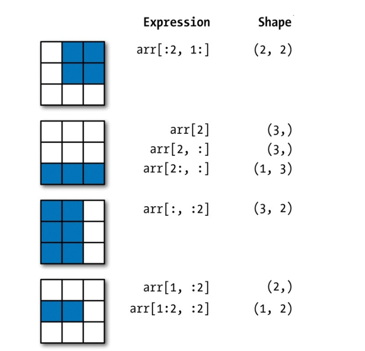

```python
#通过布尔型数组设置值
import numpy as np
data=np.random.randn(7,4)
print(data)
data[data<0]=0
print(data)
```

```
[[-1.13306565  0.39097993 -0.52293329  0.2306882 ]
 [ 1.55275434  0.33253062  1.71863739  0.09753338]
 [-2.1095241  -0.08201414 -0.88104182  1.35392322]
 [ 0.40518603 -0.51760936  0.02569261  1.30758171]
 [ 0.62287114  1.71295559  2.23779834 -2.10268664]
 [-1.59881337 -0.9590793   1.83881366  1.83032815]
 [ 0.59835235  0.37891205  0.49323004  0.26653095]]
[[0.         0.39097993 0.         0.2306882 ]
 [1.55275434 0.33253062 1.71863739 0.09753338]
 [0.         0.         0.         1.35392322]
 [0.40518603 0.         0.02569261 1.30758171]
 [0.62287114 1.71295559 2.23779834 0.        ]
 [0.         0.         1.83881366 1.83032815]
 [0.59835235 0.37891205 0.49323004 0.26653095]]
```

```python
#花式索引,无论数组是多少维的，花式索引总是一维的.
#与切片不一样，它总是将数据复制到新数组中
arr=np.empty((8,4))
for i in range(8):
    arr[i]=i
print(arr)
print(arr[[4,3,0,6]])
print(arr[[-1,-2,-3]])
```

```
[[0. 0. 0. 0.]
 [1. 1. 1. 1.]
 [2. 2. 2. 2.]
 [3. 3. 3. 3.]
 [4. 4. 4. 4.]
 [5. 5. 5. 5.]
 [6. 6. 6. 6.]
 [7. 7. 7. 7.]]
[[4. 4. 4. 4.]
 [3. 3. 3. 3.]
 [0. 0. 0. 0.]
 [6. 6. 6. 6.]]
[[7. 7. 7. 7.]
 [6. 6. 6. 6.]
 [5. 5. 5. 5.]]
```

```python
#一次传入多个索引数组，返回一个一维数组
import numpy as np
arr=np.arange(32).reshape((8,4))
print(arr)
print(arr[[1,5,7,2],[0,3,1,2]])
```

```
[[ 0  1  2  3]
 [ 4  5  6  7]
 [ 8  9 10 11]
 [12 13 14 15]
 [16 17 18 19]
 [20 21 22 23]
 [24 25 26 27]
 [28 29 30 31]]
[ 4 23 29 10]
```

```python
#返回的形式是矩阵
import numpy as np
arr=np.arange(32).reshape((8,4))
print(arr[[1,5,7,2]][:,[0,3,1,2]])
```

```
[[ 4  7  5  6]
 [20 23 21 22]
 [28 31 29 30]
 [ 8 11  9 10]]
```

### 5）array合并

```python
import numpy as np
A=np.array([1,1,1])
B=np.array([2,2,2])
print(np.vstack((A,B)))#vertical stack 上下合并
print(np.hstack((A,B)))#horizontal stack 左右合并
print(A[np.newaxis,:])#在行上加一个维度,变成矩阵
print(A[:,np.newaxis])#在列上加一个维度，变成矩阵
A=np.array([1,1,1])[:,np.newaxis]
B=np.array([2,2,2])[:,np.newaxis]
print(A)
print(B)
C=np.concatenate((A,B,B,A),axis=0)#上下合并
print(C)
D=np.concatenate((A,B,B,A),axis=1)#左右合并
print(D)
```

```
[[1 1 1]
 [2 2 2]]
[1 1 1 2 2 2]
[[1 1 1]]
[[1]
 [1]
 [1]]
[[1]
 [1]
 [1]]
[[2]
 [2]
 [2]]
[[1]
 [1]
 [1]
 [2]
 [2]
 [2]
 [2]
 [2]
 [2]
 [1]
 [1]
 [1]]
[[1 2 2 1]
 [1 2 2 1]
 [1 2 2 1]]
```

### 6）array分割

```python
import numpy as np
A=np.arange(12).reshape((3,4))
print(A)
print(np.split(A,2,axis=1))#1代表横轴，把每行切成两部分
print(np.split(A,3,axis=0))#0代表纵轴，把每列切成三部分
print(np.array_split(A,3,axis=1))#不均等分割
print(np.vsplit(A,3))#对纵轴分割
print(np.hsplit(A,2))#对横轴分割
```

```
[[ 0  1  2  3]
 [ 4  5  6  7]
 [ 8  9 10 11]]
[array([[0, 1],
       [4, 5],
       [8, 9]]), array([[ 2,  3],
       [ 6,  7],
       [10, 11]])]
[array([[0, 1, 2, 3]]), array([[4, 5, 6, 7]]), array([[ 8,  9, 10, 11]])]
[array([[0, 1],
       [4, 5],
       [8, 9]]), array([[ 2],
       [ 6],
       [10]]), array([[ 3],
       [ 7],
       [11]])]
[array([[0, 1, 2, 3]]), array([[4, 5, 6, 7]]), array([[ 8,  9, 10, 11]])]
[array([[0, 1],
       [4, 5],
       [8, 9]]), array([[ 2,  3],
       [ 6,  7],
       [10, 11]])]
```

## 2 利用数组进行数据处理

NumPy数组可以将多种数据处理任务表述为简洁的数组表达式（否则需要编写循环）。用数组表达式代替循环的做法，称为矢量化。

### 1) np.meshgrid

```python
#np.meshgrid函数接受两个一维数组，并产生两个二维矩阵
import numpy as np
points=np.arange(-5,5,1)
xs,ys=np.meshgrid(points,points)
print(xs)
print(ys)
z=np.sqrt(xs**2+ys**2)
print(z)
```

```
[[-5 -4 -3 -2 -1  0  1  2  3  4]
 [-5 -4 -3 -2 -1  0  1  2  3  4]
 [-5 -4 -3 -2 -1  0  1  2  3  4]
 [-5 -4 -3 -2 -1  0  1  2  3  4]
 [-5 -4 -3 -2 -1  0  1  2  3  4]
 [-5 -4 -3 -2 -1  0  1  2  3  4]
 [-5 -4 -3 -2 -1  0  1  2  3  4]
 [-5 -4 -3 -2 -1  0  1  2  3  4]
 [-5 -4 -3 -2 -1  0  1  2  3  4]
 [-5 -4 -3 -2 -1  0  1  2  3  4]]
[[-5 -5 -5 -5 -5 -5 -5 -5 -5 -5]
 [-4 -4 -4 -4 -4 -4 -4 -4 -4 -4]
 [-3 -3 -3 -3 -3 -3 -3 -3 -3 -3]
 [-2 -2 -2 -2 -2 -2 -2 -2 -2 -2]
 [-1 -1 -1 -1 -1 -1 -1 -1 -1 -1]
 [ 0  0  0  0  0  0  0  0  0  0]
 [ 1  1  1  1  1  1  1  1  1  1]
 [ 2  2  2  2  2  2  2  2  2  2]
 [ 3  3  3  3  3  3  3  3  3  3]
 [ 4  4  4  4  4  4  4  4  4  4]]
[[7.07106781 6.40312424 5.83095189 5.38516481 5.09901951 5.
  5.09901951 5.38516481 5.83095189 6.40312424]
 [6.40312424 5.65685425 5.         4.47213595 4.12310563 4.
  4.12310563 4.47213595 5.         5.65685425]
 [5.83095189 5.         4.24264069 3.60555128 3.16227766 3.
  3.16227766 3.60555128 4.24264069 5.        ]
 [5.38516481 4.47213595 3.60555128 2.82842712 2.23606798 2.
  2.23606798 2.82842712 3.60555128 4.47213595]
 [5.09901951 4.12310563 3.16227766 2.23606798 1.41421356 1.
  1.41421356 2.23606798 3.16227766 4.12310563]
 [5.         4.         3.         2.         1.         0.
  1.         2.         3.         4.        ]
 [5.09901951 4.12310563 3.16227766 2.23606798 1.41421356 1.
  1.41421356 2.23606798 3.16227766 4.12310563]
 [5.38516481 4.47213595 3.60555128 2.82842712 2.23606798 2.
  2.23606798 2.82842712 3.60555128 4.47213595]
 [5.83095189 5.         4.24264069 3.60555128 3.16227766 3.
  3.16227766 3.60555128 4.24264069 5.        ]
 [6.40312424 5.65685425 5.         4.47213595 4.12310563 4.
  4.12310563 4.47213595 5.         5.65685425]]
```

### 2) 将条件逻辑表述为数组运算

运用np.where函数，第二个和第三个参数不必是数组，它们都可以是标量值。

```python
#当cond中为True,选取xarr的值，否则选取yarr的值
import numpy as np
xarr=np.array([1.1,1.2,1.3,1.4,1.5])
yarr=np.array([2.1,2.2,2.3,2.4,2.5])
cond=np.array([True,False,True,True,False])
result=np.where(cond,xarr,yarr)
print(result)
```

```
[1.1 2.2 1.3 1.4 2.5]
```

```python
#有一个由随机数生成的矩阵，将所有正值替换成2，将所有负值替换成-2
import numpy as np
arr=np.random.randn(4,4)
print(arr)
print(arr>0)
print(np.where(arr>0,2,-2))
```

```
[[ 0.78025019  0.97327091 -2.00407112 -0.91709059]
 [-0.57068838  0.88517403  1.04968076  0.35206013]
 [ 0.27193988  0.22499349 -0.03306399 -0.13699435]
 [ 1.99985467  0.04919932  0.37386496  1.83093805]]
[[ True  True False False]
 [False  True  True  True]
 [ True  True False False]
 [ True  True  True  True]]
[[ 2  2 -2 -2]
 [-2  2  2  2]
 [ 2  2 -2 -2]
 [ 2  2  2  2]]
```

### 3) 数学和统计方法

可以通过数组上的一组数学函数对整个数组或某个轴向的数据进行统计计算。

```python
#聚类统计
import numpy as np
arr=np.random.randn(5,4)
print(arr)
print(arr.mean())
print(np.mean(arr))
print(arr.sum())
print(arr.mean(axis=1))#计算行的平均值
print(arr.sum(axis=0))#计算每列的和
```

[output not shown]

```python
import numpy as np
arr=np.arange(9).reshape(3,3)
print(arr)
print(arr.cumsum(axis=0))#累计和
print(arr.cumprod(axis=1))#累计积
```

```
[[0 1 2]
 [3 4 5]
 [6 7 8]]
[[ 0  1  2]
 [ 3  5  7]
 [ 9 12 15]]
[[  0   0   0]
 [  3  12  60]
 [  6  42 336]]
```

### 4）用于布尔型数组的方法

这两个方法也可以用于非布尔型数组，所以非0元素会被当成True

```python
import numpy as np
arr=np.random.randn(10)
print((arr>0).sum())#有多少正数
```

```
8
```

```python
import numpy as np
bools=np.array([False,False,True])
print(bools.any())#判断是否存在True
print(bools.all())#判断是否全是True
```

```
True
False
```

### 5) 排序

NumPy数组也可以通过sort方法就地排序

```python
#多维数组可以在任何一个轴向上进行排序，只需将轴编号传给sort即可
import numpy as np
arr=np.random.randn(5,3)
print(arr)
arr.sort(0)
print(arr)
```

```
[[ 0.70322036 -0.43094028  0.14387952]
 [-0.28923438  0.24368556 -0.11943957]
 [-1.37817236  0.20490871  0.3786006 ]
 [-0.45546753  1.69067303 -0.06053976]
 [-1.05379879 -0.28658286 -0.3523893 ]]
[[-1.37817236 -0.43094028 -0.3523893 ]
 [-1.05379879 -0.28658286 -0.11943957]
 [-0.45546753  0.20490871 -0.06053976]
 [-0.28923438  0.24368556  0.14387952]
 [ 0.70322036  1.69067303  0.3786006 ]]
```

### 6) 唯一化以及它的集合逻辑

np.unique用于找出数组中的唯一值并返回已排序的结果

np.in1d用于测试一个数组中的值在另一个数组中的成员资格，返回一个布尔型数组

```python
#np.unique
import numpy as np
ints=np.array([25,25,9,2,4,6,6,6,7,7])
np.unique(ints)
```

```
array([ 2,  4,  6,  7,  9, 25])
```

```python
import numpy as np
values=np.array([4,4,5,2,2,6,7])
np.in1d(values,[4,5])
```

```
array([ True,  True,  True, False, False, False, False])
```

## 3 用于数组的文件输入输出

np.save和np.load是读写磁盘数组数据的两个主要函数。默认情况下，数组是以未压缩的原始二进制格式保存在.npy的文件中的。

通过np.savez可以将多个数组保存到一个未压缩文件中，将数组以关键字参数的形式传入即可。

```python
#np.save&np.load
import numpy as np
arr=np.arange(10)
np.save('some_array',arr)
np.load('some_array.npy')
```

```
array([0, 1, 2, 3, 4, 5, 6, 7, 8, 9])
```

```python
#np.savez
import numpy as np
np.savez('array_archive.npz',a=arr,b=arr)
arch=np.load('array_archive.npz')
arch['b']
```

```
array([0, 1, 2, 3, 4, 5, 6, 7, 8, 9])
```

## 4 线性代数

NumPy提供了一个用于矩阵乘法的dot函数

@符也可用作中缀运算符，进行矩阵乘法

```python
import numpy as np
x=np.array([[1,2,3],[4,5,6]])
x@np.ones(3)
```

```
array([ 6., 15.])
```

numpy.linalg中有一组标准的矩阵分解运算以及诸如求逆和行列式之类的东西

```python
import numpy as np
from numpy.linalg import inv,qr
x=np.random.randn(5,5)
mat=x.T.dot(x)
print(inv(mat))#求逆
print(mat.dot(inv(mat)))
q,r=qr(mat)
print(q)
print(r)
```

```
[[ 0.3650879   0.05627772  0.01542176  0.13748711  0.03972675]
 [ 0.05627772  0.5190207  -0.14248769 -0.21570203  0.3452958 ]
 [ 0.01542176 -0.14248769  0.3636715   0.10438884  0.11139872]
 [ 0.13748711 -0.21570203  0.10438884  0.35114921 -0.25066227]
 [ 0.03972675  0.3452958   0.11139872 -0.25066227  0.91214361]]
[[ 1.00000000e+00  4.74983022e-18  1.74099696e-18 -3.78140532e-17
  -3.91419046e-18]
 [-3.71544163e-17  1.00000000e+00  1.77890634e-17 -2.97110296e-17
   1.00899293e-16]
 [ 1.02840061e-17  1.23848831e-16  1.00000000e+00 -1.16248261e-16
  -3.61456854e-17]
 [-1.34031015e-16  1.87583466e-16 -1.66061955e-16  1.00000000e+00
   2.16493247e-16]
 [-5.05437270e-17 -1.94768927e-16 -4.66241015e-17  1.47582541e-16
   1.00000000e+00]]
[[-0.796608   -0.18582723  0.38296233 -0.42742092  0.03918095]
 [ 0.22149184 -0.82133395  0.31012981  0.253369    0.34055182]
 [-0.07012324 -0.40432184 -0.80829467 -0.40767055  0.10986823]
 [ 0.5471645  -0.06046037  0.31798284 -0.73124927 -0.24721844]
 [ 0.10977611  0.35177716  0.05201914 -0.22846165  0.89961176]]
[[-5.0035225   2.3447819  -1.27642048  6.2900797   1.33507891]
 [ 0.         -4.08784335 -3.44398656  0.0258296   2.36083716]
 [ 0.          0.         -3.41007436  2.80814873  1.24519208]
 [ 0.          0.          0.         -2.81306439 -1.0235129 ]
 [ 0.          0.          0.          0.          0.98626111]]
```

## 5 伪随机数生成

numpy.random模块对Python内置的random进行了补充，增加了一些用于高效生成多种概率分布的样本值的函数。

可以用normal来得到一个标准正态分布的4×4样本数组

```python
import numpy as np
samples=np.random.normal(size=(4,4))
samples
```

```
array([[-3.10713801,  0.47032513,  1.85706931, -0.66794689],
       [-0.57777985, -0.28685284, -0.2486567 , -0.72961292],
       [ 2.38111034,  1.14070815,  0.88412935, -0.23191663],
       [ 0.32040464, -0.95131868, -0.30126904, -0.35334777]])
```

可以用np.random.seed更改随机数生成种子

```python
import numpy as np
np.random.seed(1234)
```

numpy.random的数据生成函数使用了全局的随机种子。要避免全局状态，可以使用numpy.random.RandomState,创建一个与其他隔离的随机数生成器

```python
import numpy as np
rng=np.random.RandomState(1234)
rng.randn(10)
```

```
array([ 0.47143516, -1.19097569,  1.43270697, -0.3126519 , -0.72058873,
        0.88716294,  0.85958841, -0.6365235 ,  0.01569637, -2.24268495])
```

## 6 随机漫步

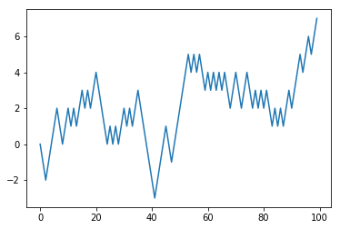

```python
import random
import matplotlib.pyplot as plt
position=0
walk=[position]
steps=1000
for i in range(steps):
    step=1 if random.randint(0,1) else -1
    position+=step
    walk.append(position)
plt.figure()
plt.plot(walk[:100])
plt.show()
```

用np.random模块一次性随机产生1000个“掷硬币”结果，分别设置为1，-1，然后计算累计和

```python
import random
nsteps=1000
draws=np.random.randint(0,2,size=nsteps)
steps=np.where(draws>0,1,-1)
walk=steps.cumsum()
print(walk.min())
print(walk.max())
(np.abs(walk)>=10).argmax()#返回第一个10或-10的索引
```

```
0
55
```

```
13
```

一次模拟多个随机漫步

```python
import numpy as np
import random
nwalks=5000
nsteps=1000
draws=np.random.randint(0,2,size=(nwalks,nsteps))
steps=np.where(draws>0,1,-1)
walks=steps.cumsum(1)
print(walks)
print(walks.max())
print(walks.min())
hits30=(np.abs(walks)>=30).any(1)
print(hits30)
print(hits30.sum())
crossing_times=(np.abs(walks[hits30])>=30).argmax()
crossing_times.mean()
```

```
[[  1   0  -1 ...   0  -1  -2]
 [ -1  -2  -3 ... -10  -9  -8]
 [ -1  -2  -1 ...   4   5   6]
 ...
 [ -1   0   1 ...  40  39  38]
 [  1   0   1 ...  -8  -7  -8]
 [ -1  -2  -1 ... -18 -19 -18]]
106
-128
[ True False  True ...  True  True False]
3405
```

```
409.0
```

## 7 最后

如果想要查看完整视频，请点击https://mofanpy.com/tutorials/data-manipulation/np-pd/

注明：本文档由Jupyter Notebook编辑并导出，每个代码块下方是运行结果，可供参考。